# Chapter 5. Clustering and classification

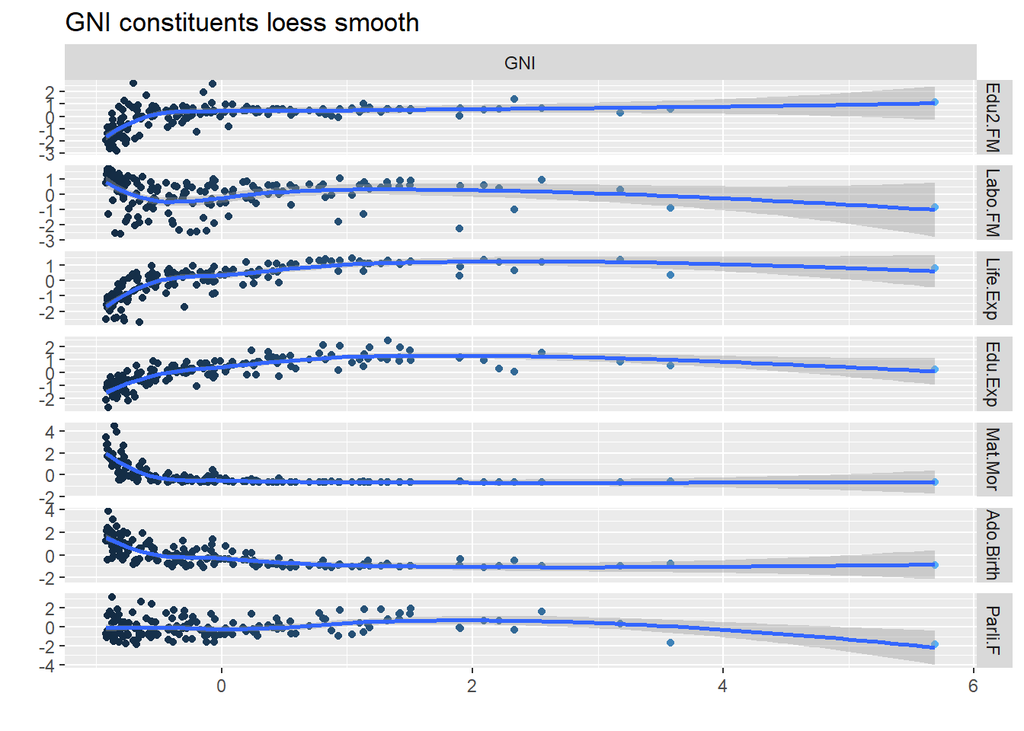

```r
ggduo(
  human_std, 5, c(1:4,6:8),
  types = list(continuous = "smooth_loess", mapping = aes(color = GNI)),
  title = "GNI constituents loess smooth",
  xlab = "",
  ylab = ""
)
```

The scaled dataset looks very similar, however, some extreme values are now drawn more closer.

```r
# Running the principal component analysis'
pca_human       <- prcomp(human)
pca_human_std   <- prcomp(human_std)

# comparison summaries
s_pca_human     <- summary(pca_human)
s_pca_human_std <- summary(pca_human_std)
s_pca_human
```

```
## Importance of components:
##                              PC1      PC2   PC3   PC4   PC5   PC6    PC7
## Standard deviation     1.854e+04 185.5219 25.19 11.45 3.766 1.566 0.1912
## Proportion of Variance 9.999e-01   0.0001  0.00  0.00 0.000 0.000 0.0000
## Cumulative Proportion  9.999e-01   1.0000  1.00  1.00 1.000 1.000 1.0000
##                           PC8
## Standard deviation     0.1591
## Proportion of Variance 0.0000
## Cumulative Proportion  1.0000
```

```r
s_pca_human_std
```

```
## Importance of components:
##                           PC1    PC2     PC3     PC4     PC5     PC6
## Standard deviation     2.0708 1.1397 0.87505 0.77886 0.66196 0.53631
## Proportion of Variance 0.5361 0.1624 0.09571 0.07583 0.05477 0.03595
## Cumulative Proportion  0.5361 0.6984 0.79413 0.86996 0.92473 0.96069
##                            PC7     PC8
## Standard deviation     0.45900 0.32224
## Proportion of Variance 0.02634 0.01298
## Cumulative Proportion  0.98702 1.00000
```

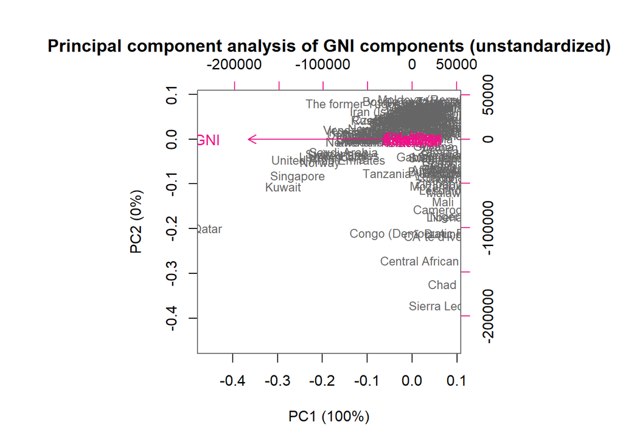

```r
# Generating labels
pca_pr      <- round(100*s_pca_human$importance[2, ], digits = 1)
pca_pr_std <- round(100*s_pca_human_std$importance[2, ], digits = 1)
pca_pr_lab <- paste0(names(pca_pr), " (", pca_pr, "%)")
pca_pr_lab_std <- paste0(names(pca_pr_std), " (", pca_pr_std, "%)")

#Plotting 2

biplot(
  pca_human, cex = c(0.8, 1),
  col = c("grey40", "deeppink2"),
  xlab = pca_pr_lab[1],
  ylab = pca_pr_lab[2],
  main= "Principal component analysis of GNI components (unstandardized)"
)
```

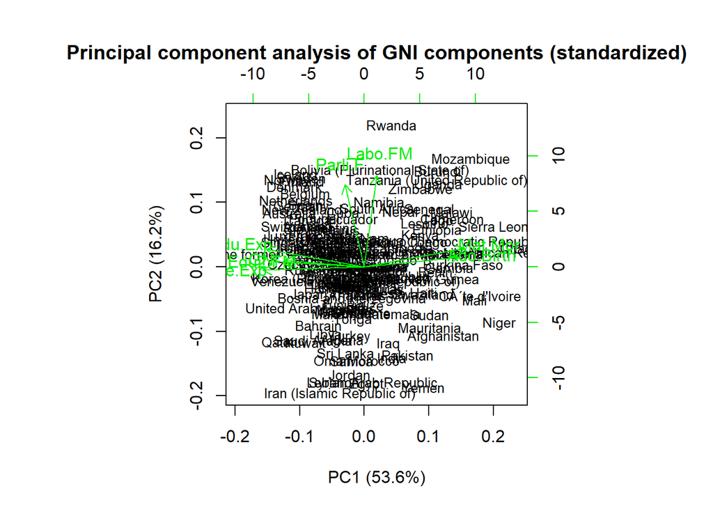

```r
biplot(
  pca_human_std,
  cex = c(0.8, 1),
  col = c("black", "green2"),
  xlab = pca_pr_lab_std[1],
  ylab = pca_pr_lab_std[2],
  main= "Principal component analysis of GNI components (standardized)"
)
```

Non-scaled results are non-usable. All the nearly all deviation are explained by the first dimension as the uneven scale makes the big numbers have huge importance.

### GNI Data standardized PCA results for the 1st and 2nd dimension:

| Variables | Description | PC1 | PC2 |
| --- | --- | --- | --- |
| Edu2.FM | Secondary education Female/male index | -0.35664370 | 0.03796058 |
| Labo.F | Female labour participation rate | 0.05457785 | 0.72432726 |
| Life.Exp | Life expentancy at birth | -0.44372240 | -0.02530473 |
| Edu.Exp | Educational expentancy | -0.42766720 | 0.13940571 |
| GNI | Gender Development index | -0.35048295 | 0.05060876 |
| Mat.Mor | Mortality of mothers | 0.43697098 | 0.14508727 |
| Ado.Birth | Adolecent birth rate | 0.41126010 | 0.07708468 |
| Parli.F | Parlamentary represtantion of females | -0.08438558 | 0.65136866 |

PCA splits the data to eight dimensions where first three explain 79 % of the variance. First two dimensions explain 69 %. Horizontal dimension is explained by education and life expectancy and Gender development index, and to the right (positive) dimension is explained by mortality of mothers and adolecent brith rate. 2nd dimension is explained by parlamentary representation of females and labor participation ratio.

```r
data(tea)

keep_columns <- c("Tea", "How", "how", "sugar", "where", "lunch")

# select the 'keep_columns' to create a new dataset
tea_time <- select(tea, one_of(keep_columns))

# look at the summaries and structure of the data
tea_time %>% summary()
```

```
##         Tea         How                      how           sugar
##  black    : 74   alone:195   tea bag           :170   No.sugar:155
##  Earl Grey:193   lemon: 33   tea bag+unpackaged: 94   sugar   :145
##  green    : 33   milk : 63   unpackaged        : 36
##                  other:  9
##                   where           lunch
##  chain store         :192   lunch    : 44
##  chain store+tea shop: 78   Not.lunch:256
##  tea shop            : 30
##
```

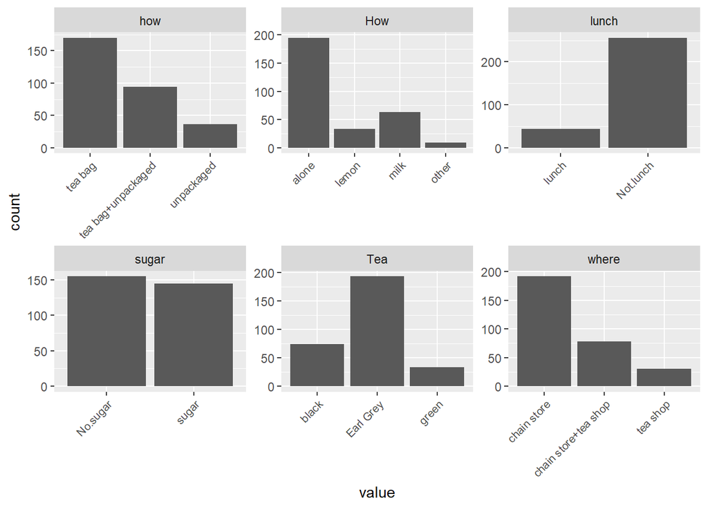

```r
#str(tea_time)

# visualize the dataset
gather(tea_time) %>% ggplot(aes(value)) + facet_wrap("key", scales = "free") + geom_bar() + theme(axis.text.x = element_text(angle = 45, hjust = 1, size = 8))
```

```r
 mca <- MCA(tea_time, graph = FALSE)

# summary of the model
summary(mca)
```

```
##
## Call:
## MCA(X = tea_time, graph = FALSE)
##
##
## Eigenvalues
##                        Dim.1   Dim.2   Dim.3   Dim.4   Dim.5   Dim.6
## Variance               0.279   0.261   0.219   0.189   0.177   0.156
## % of var.             15.238  14.232  11.964  10.333   9.667   8.519
## Cumulative % of var.  15.238  29.471  41.435  51.768  61.434  69.953
##                        Dim.7   Dim.8   Dim.9  Dim.10  Dim.11
## Variance               0.144   0.141   0.117   0.087   0.062
## % of var.              7.841   7.705   6.392   4.724   3.385
## Cumulative % of var.  77.794  85.500  91.891  96.615 100.000
##
## Individuals (the 10 first)
##                       Dim.1    ctr   cos2    Dim.2    ctr   cos2    Dim.3
## 1                  | -0.298  0.106  0.086 | -0.328  0.137  0.105 | -0.327
## 2                  | -0.237  0.067  0.036 | -0.136  0.024  0.012 | -0.695
## 3                  | -0.369  0.162  0.231 | -0.300  0.115  0.153 | -0.202
## 4                  | -0.530  0.335  0.460 | -0.318  0.129  0.166 |  0.211
## 5                  | -0.369  0.162  0.231 | -0.300  0.115  0.153 | -0.202
## 6                  | -0.369  0.162  0.231 | -0.300  0.115  0.153 | -0.202
## 7                  | -0.369  0.162  0.231 | -0.300  0.115  0.153 | -0.202
## 8                  | -0.237  0.067  0.036 | -0.136  0.024  0.012 | -0.695
## 9                  |  0.143  0.024  0.012 |  0.871  0.969  0.435 | -0.067
## 10                 |  0.476  0.271  0.140 |  0.687  0.604  0.291 | -0.650
##                       ctr   cos2
## 1                   0.163  0.104 |
## 2                   0.735  0.314 |
## 3                   0.062  0.069 |
## 4                   0.068  0.073 |
## 5                   0.062  0.069 |
## 6                   0.062  0.069 |
## 7                   0.062  0.069 |
## 8                   0.735  0.314 |
## 9                   0.007  0.003 |
## 10                  0.643  0.261 |
##
## Categories (the 10 first)
```

[output cut: 16 more lines]

```
## lemon                0.035   3.226 |   1.329  14.771   0.218   8.081 |
## milk                 0.020   2.422 |   0.013   0.003   0.000   0.116 |
## other                0.102   5.534 |  -2.524  14.526   0.197  -7.676 |
## tea bag              0.161  -6.941 |  -0.065   0.183   0.006  -1.287 |
## tea bag+unpackaged   0.478  11.956 |   0.019   0.009   0.000   0.226 |
## unpackaged           0.141  -6.482 |   0.257   0.602   0.009   1.640 |
##
## Categorical variables (eta2)
##                      Dim.1 Dim.2 Dim.3
## Tea                | 0.126 0.108 0.410 |
## How                | 0.076 0.190 0.394 |
## how                | 0.708 0.522 0.010 |
## sugar              | 0.065 0.001 0.336 |
## where              | 0.702 0.681 0.055 |
## lunch              | 0.000 0.064 0.111 |
```

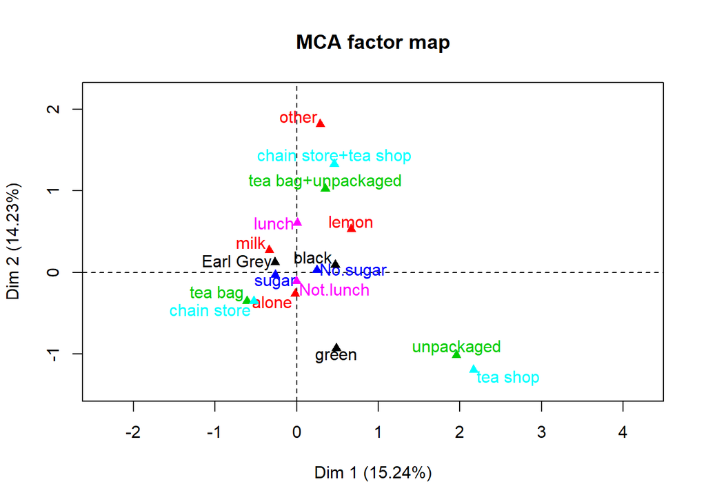

```r
# visualize MCA
 plot(mca, invisible=c("ind"), habillage = "quali")
```

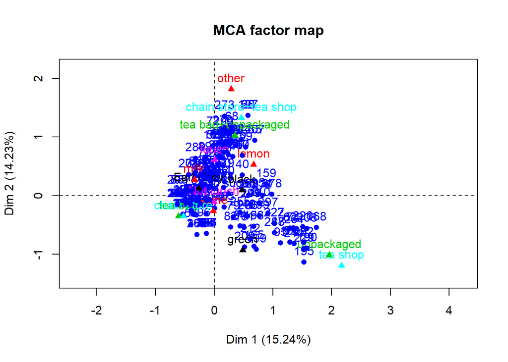

```r
 plot(mca, habillage = "quali")
```

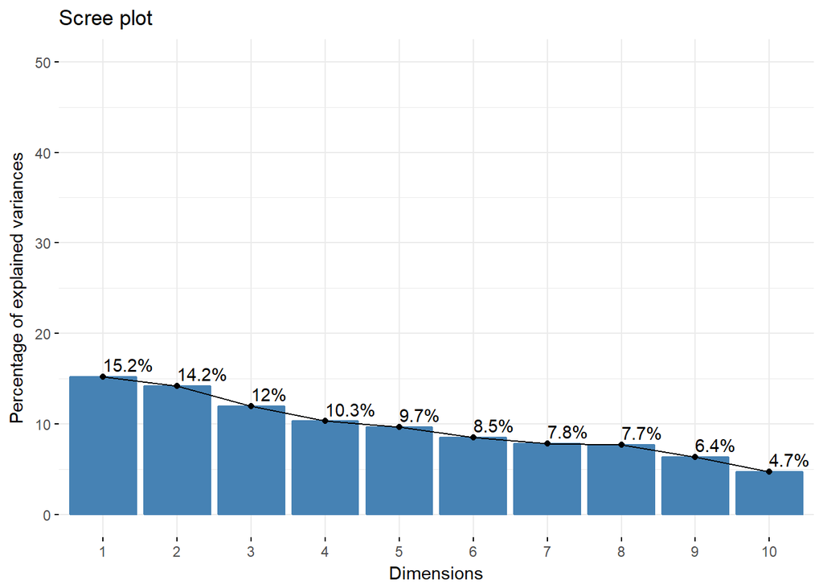

```r
 # Screeplot dimension explaining for variance
 fviz_screeplot(mca, addlabels = TRUE, ylim = c(0, 50))
```

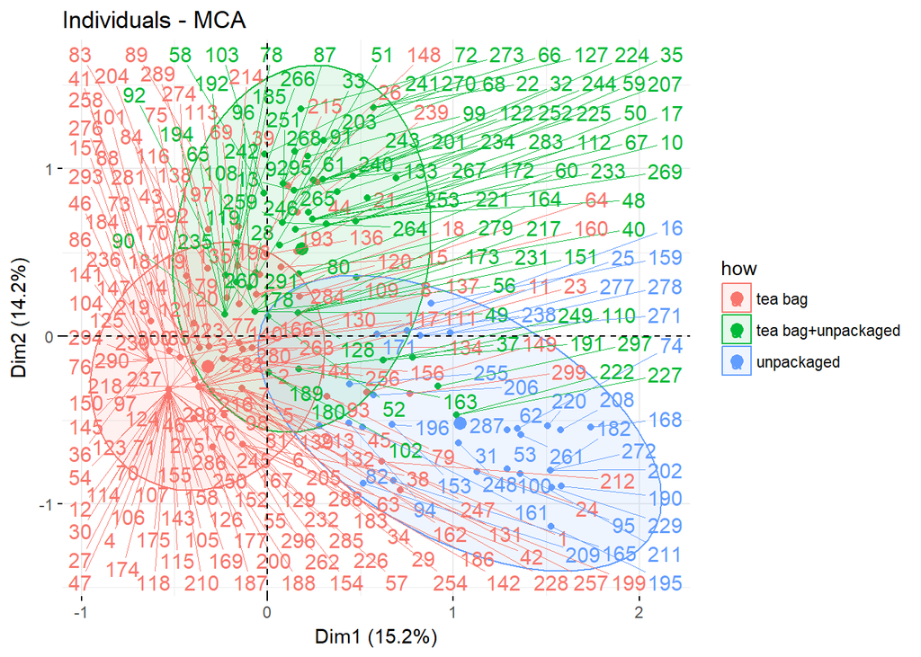

```r
 #Strongest 1 dimension
 fviz_mca_ind(mca,  habillage = "how",
              addEllipses = TRUE, repel = TRUE)
```

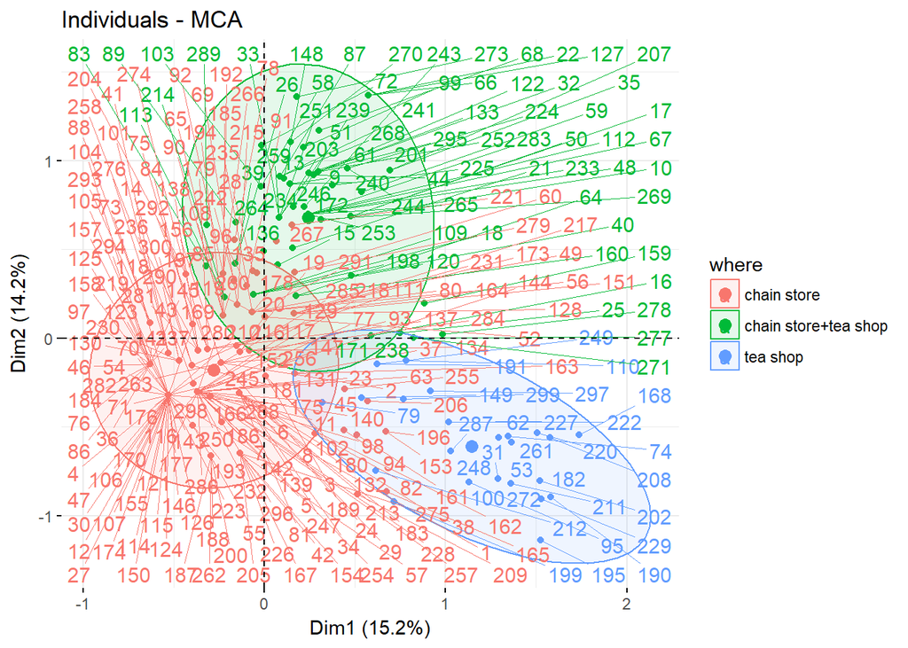

```r
 #Stronggest 2 dimension
 fviz_mca_ind(mca,  habillage = "where",
           addEllipses = TRUE, repel = TRUE)
```

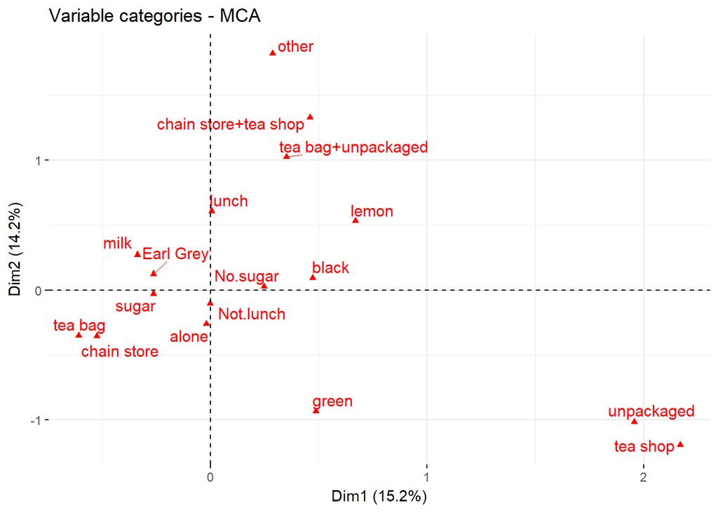

```r
 fviz_mca_var(mca, repel = TRUE)
```

1. Here none of the variables have such strong explatory power as in the example before.
2. First four dimensions explain roughly 50 % of the variance.
3. “How”" and “where” variables split the 1st and the 2nd dimension, where as the 6 dimensions, the separation of the individuals by them is not good.
4. Basically the individuals in the data set is best separate to groups by where they drink ther tea or do the drink it in premade bags or tea bags.
5. Perhaps the other notable charasteristic was the weather you like green tea or earl grey, since they seemed to differ in the dataset (3rd dimension).